## Categorical Plots

### Forecasted categorical trends for the 0-3 week horizon by Model

- CEPH-Rtrend_fluH
- CU-ensemble
- Epistorm-Ensemble_Flu
- FluSight-baseline_cat
- FluSight-dist_cat
- FluSight-ens_q_cat
- FluSight-ens_q_cat_sub
- FluSight-ensemble
- FluSight-equal_cat
- MOBS-EpyStrain_Flu
- MOBS-GLEAM_RL_FLUH
- NAU-vulPES
- PSI-PROF
- PSI-PROF_MOA
- SigSci-TSENS
- UGA_flucast-Copycat
- UVAFluX-Ensemble
- UMass-trends_ensemble

### Model: CEPH-Rtrend_fluH

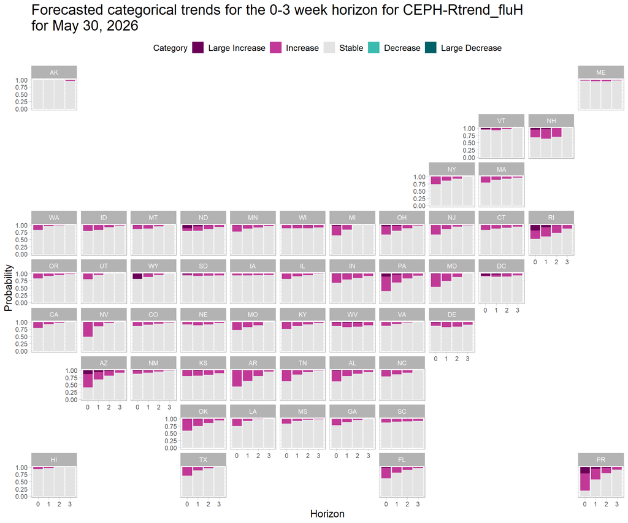

### Model: CU-ensemble

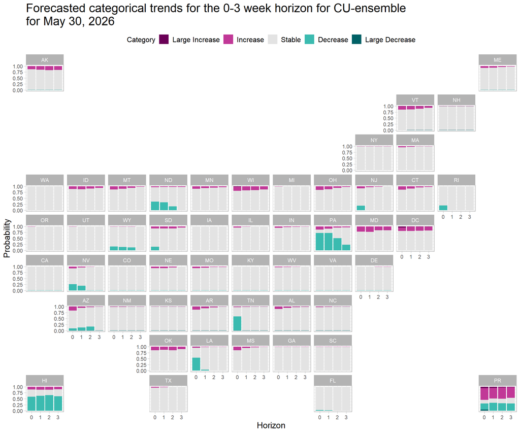

### Model: Epistorm-Ensemble_Flu

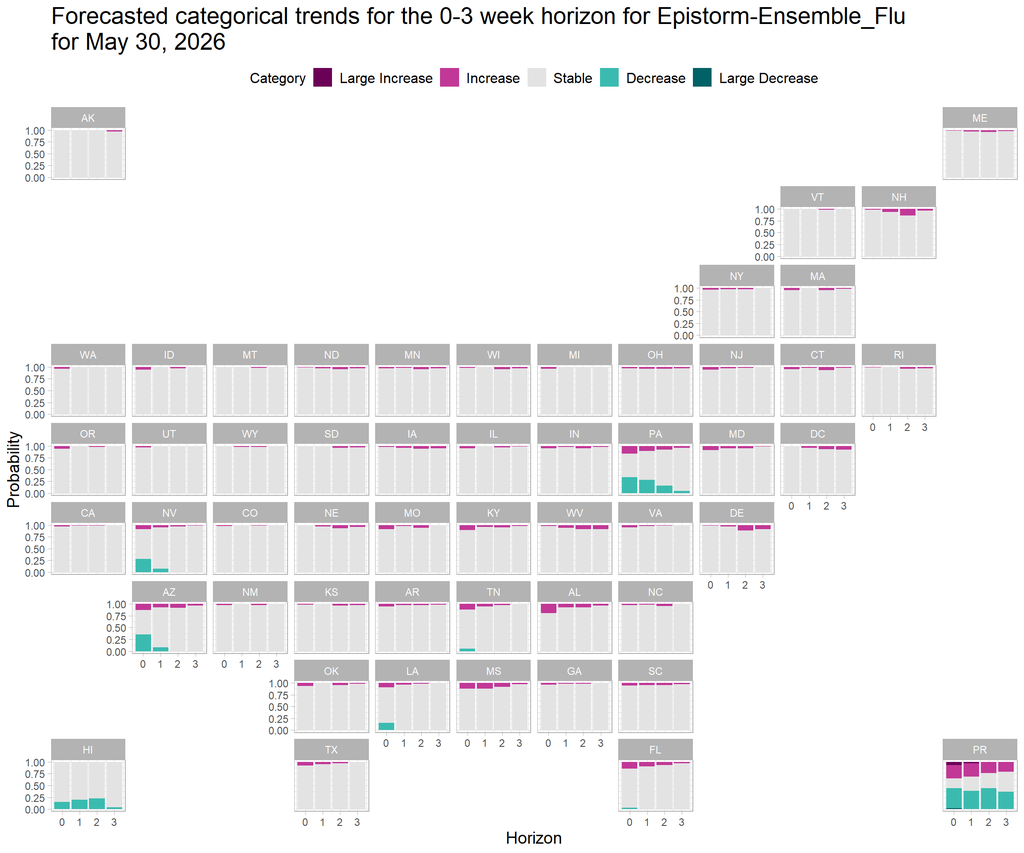

### Model: FluSight-baseline_cat

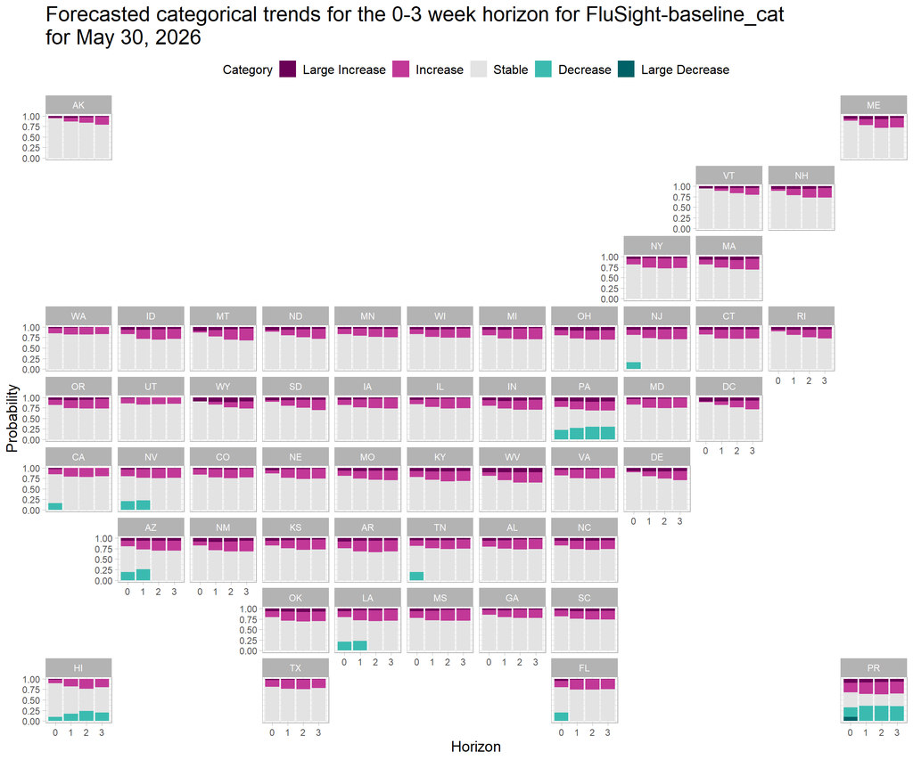

### Model: FluSight-dist_cat

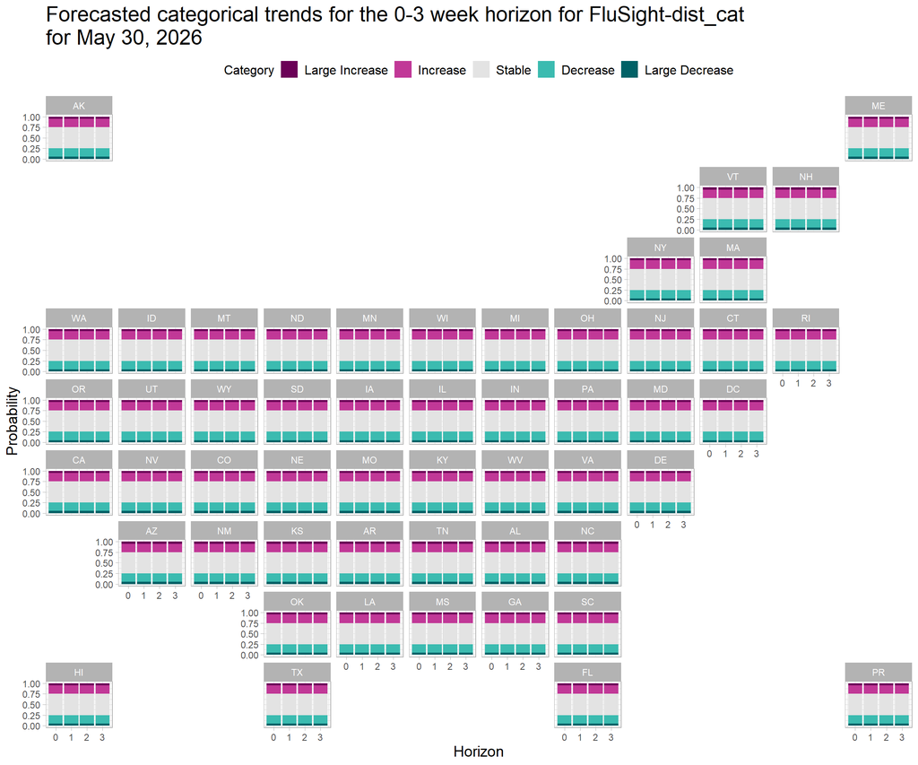

### Model: FluSight-ens_q_cat

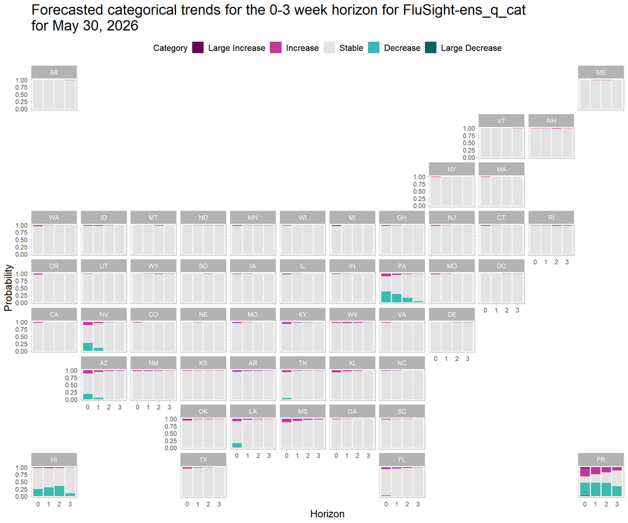

### Model: FluSight-ens_q_cat_sub

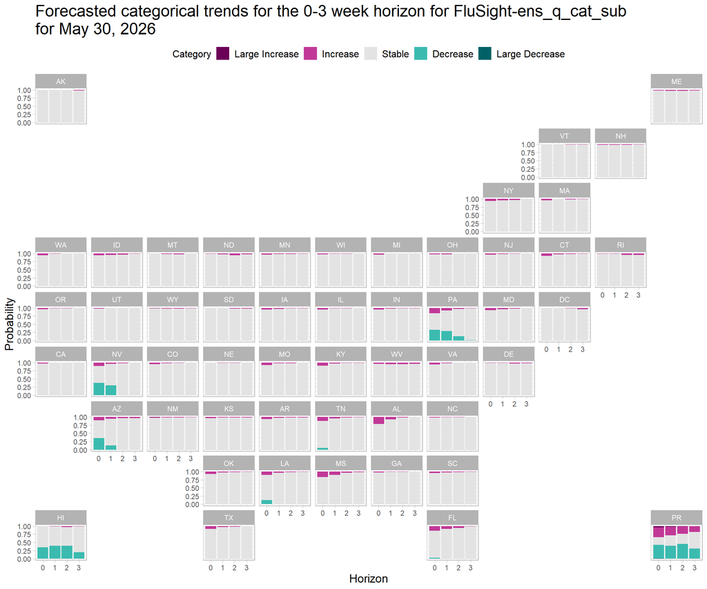

### Model: FluSight-ensemble

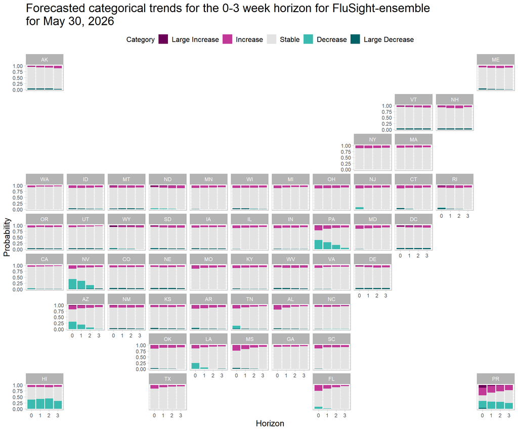

### Model: FluSight-equal_cat

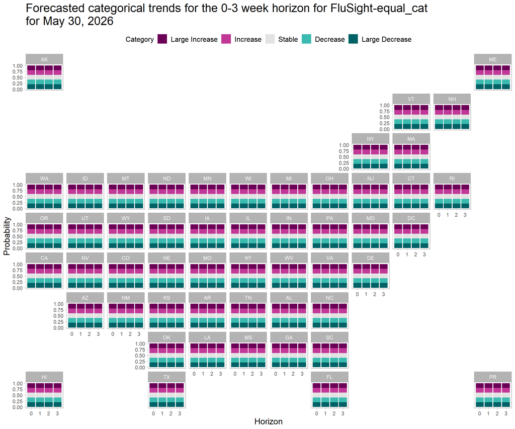

### Model: MOBS-EpyStrain_Flu

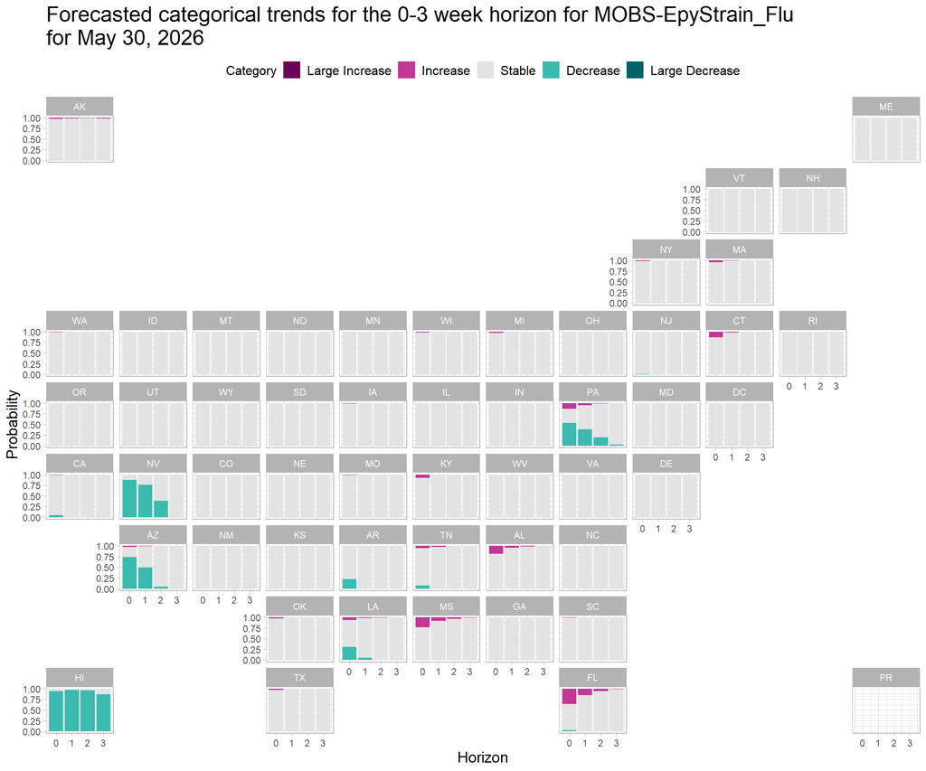

### Model: MOBS-GLEAM_RL_FLUH

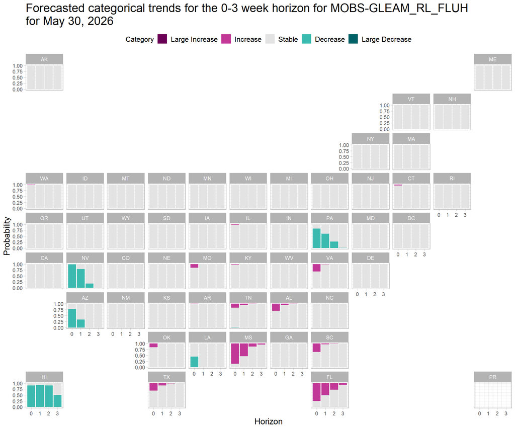

### Model: NAU-vulPES

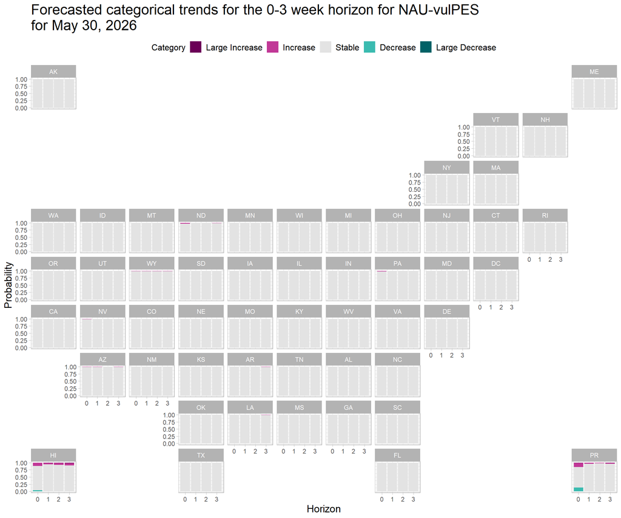

### Model: PSI-PROF

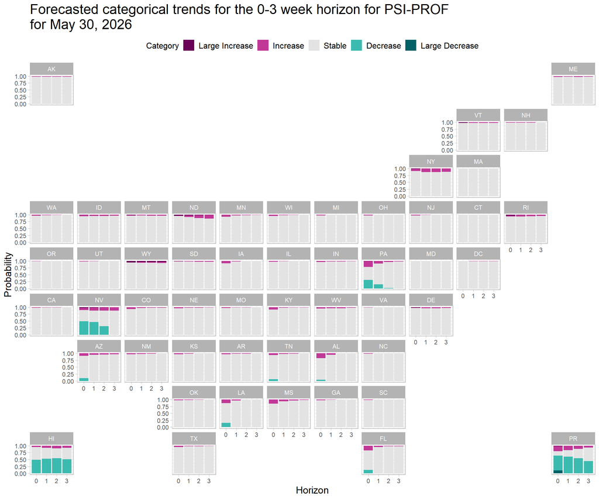

### Model: PSI-PROF_MOA

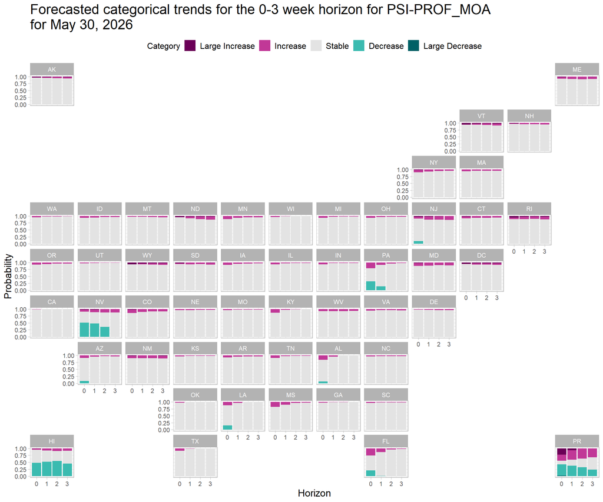

### Model: SigSci-TSENS

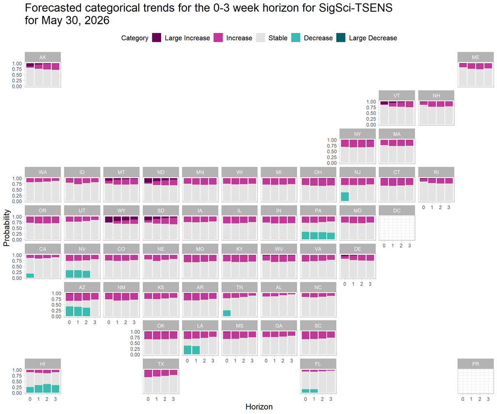

### Model: UGA_flucast-Copycat

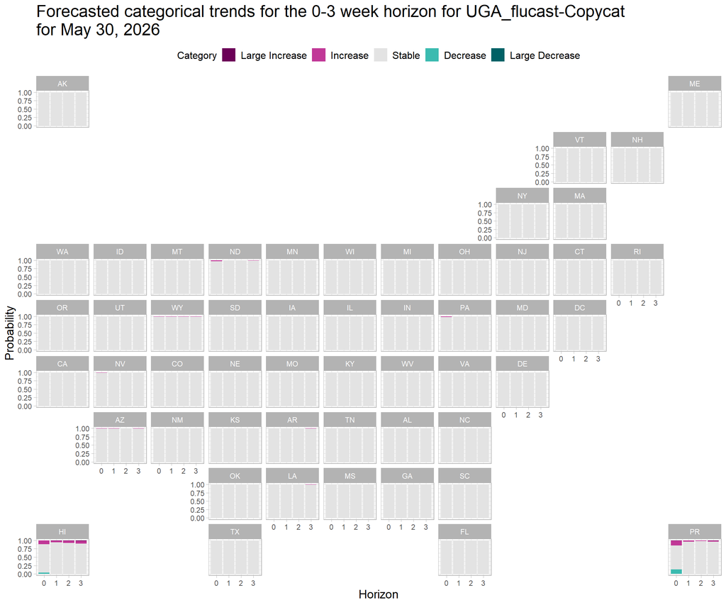

### Model: UVAFluX-Ensemble

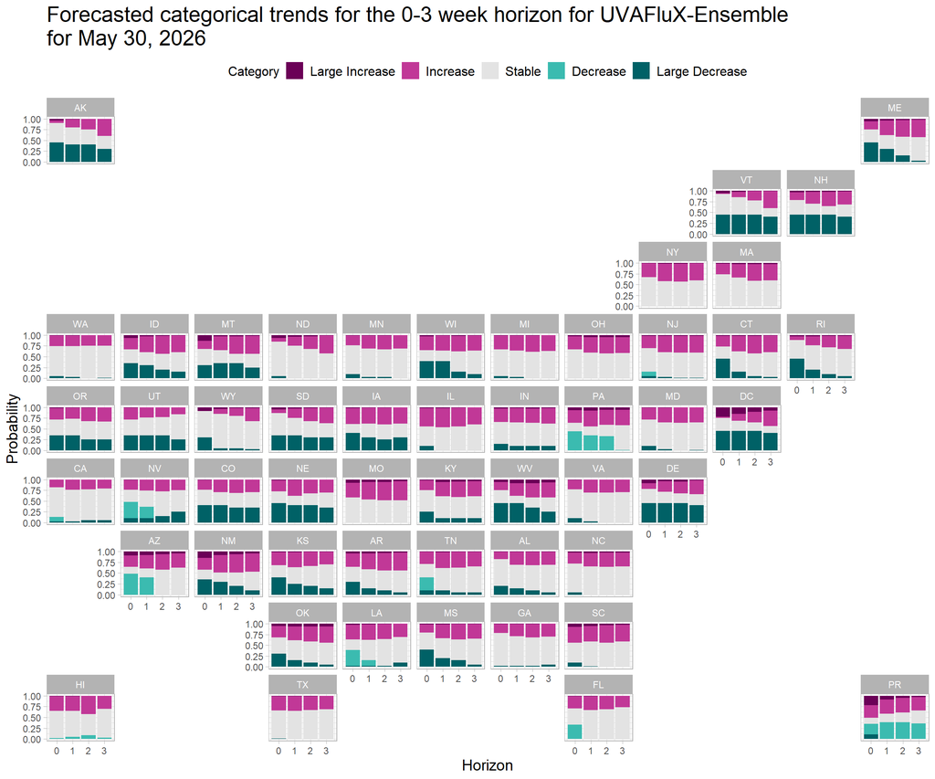

### Model: UMass-trends_ensemble

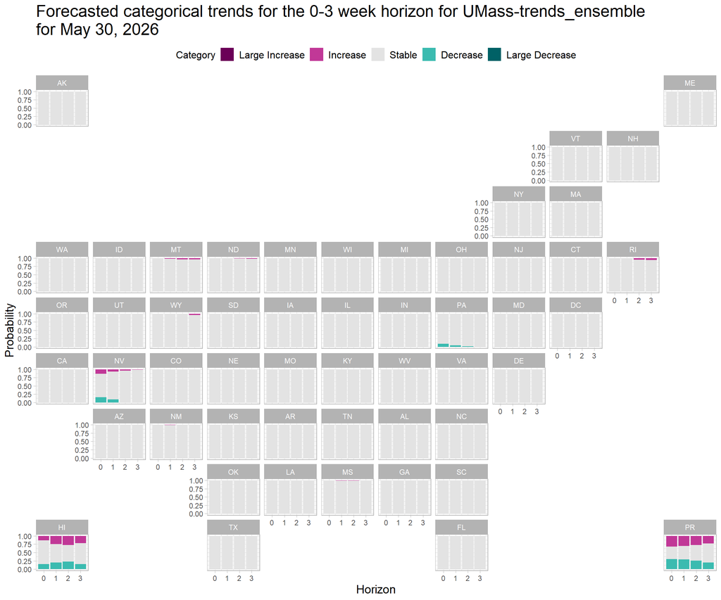

### Observed and Forecasted Categorical Trends

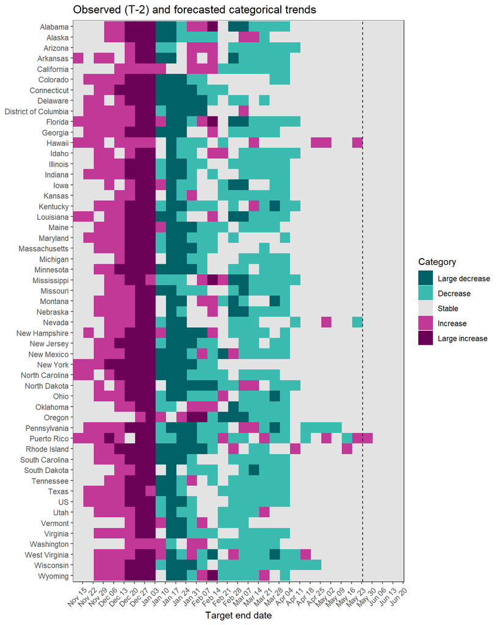

### Probability of Categorical Trend by Model and State

- State: US
- State: Alabama
- State: Alaska
- State: Arizona
- State: Arkansas
- State: California
- State: Colorado
- State: Connecticut
- State: Delaware
- State: District of Columbia
- State: Florida
- State: Georgia
- State: Hawaii
- State: Idaho
- State: Illinois
- State: Indiana
- State: Iowa
- State: Kansas
- State: Kentucky
- State: Louisiana
- State: Maine
- State: Maryland
- State: Massachusetts
- State: Michigan
- State: Minnesota
- State: Mississippi
- State: Missouri
- State: Montana
- State: Nebraska
- State: Nevada
- State: New Hampshire
- State: New Jersey
- State: New Mexico
- State: New York
- State: North Carolina
- State: North Dakota
- State: Ohio
- State: Oklahoma
- State: Oregon
- State: Pennsylvania
- State: Puerto Rico
- State: Rhode Island
- State: South Carolina
- State: South Dakota
- State: Tennessee
- State: Texas
- State: Utah
- State: Vermont
- State: Virginia
- State: Washington
- State: West Virginia
- State: Wisconsin
- State: Wyoming

### US

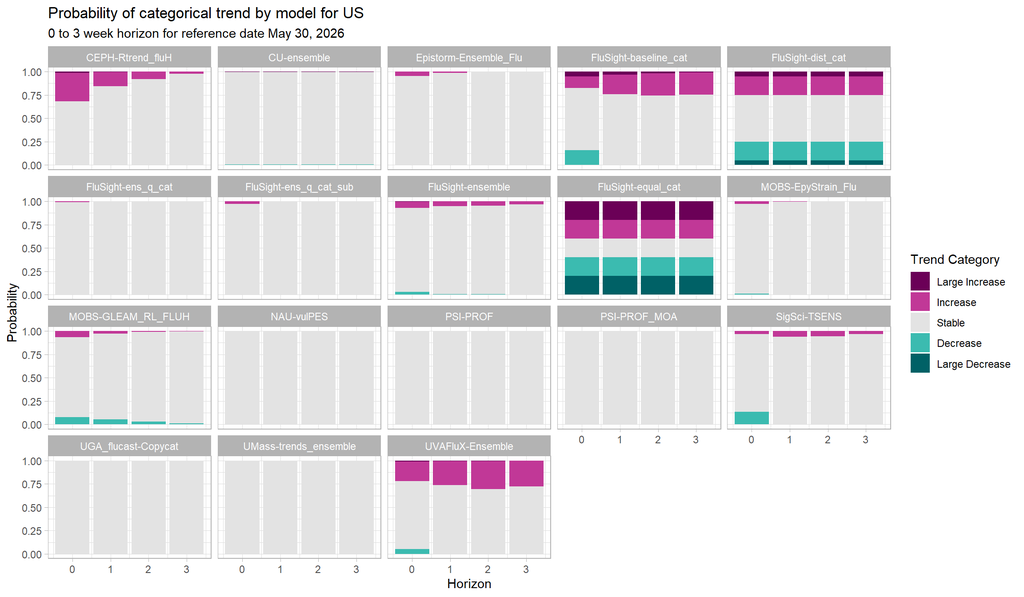

### Alabama

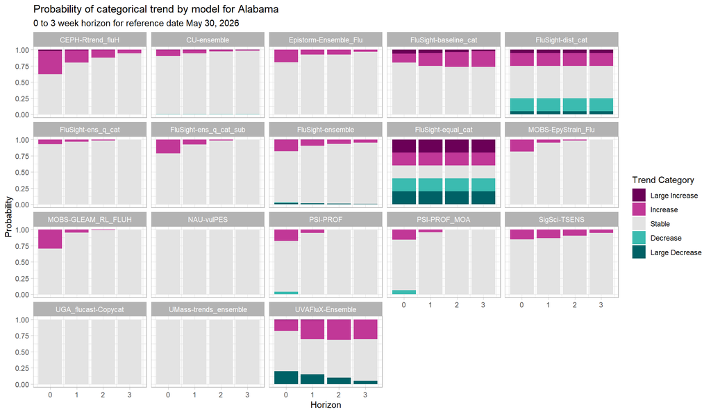

### Alaska

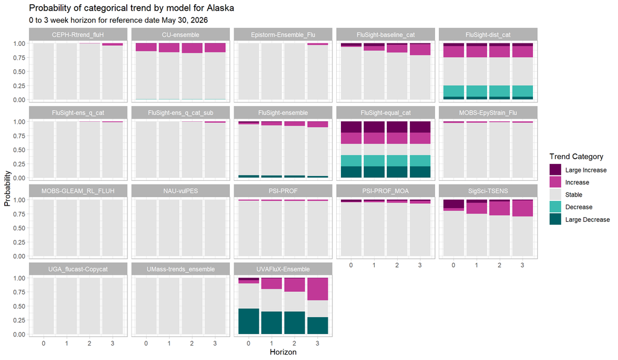

### Arizona

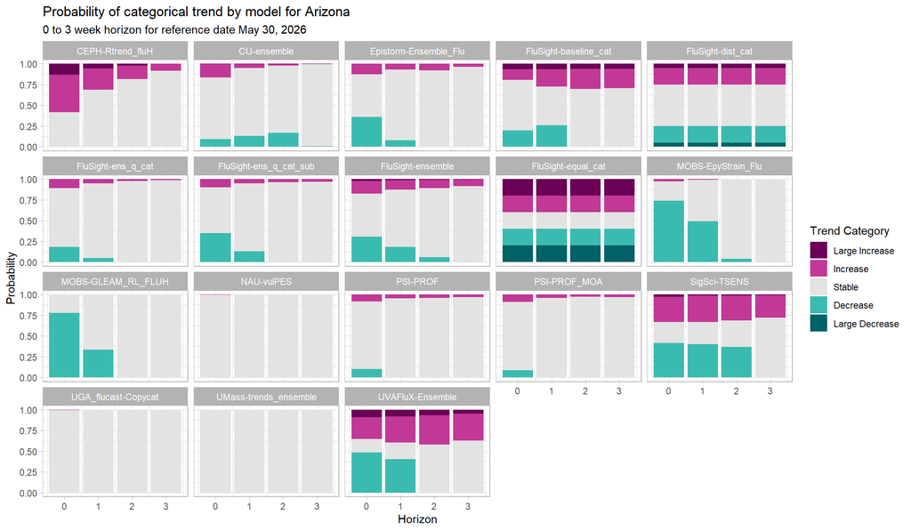

### Arkansas

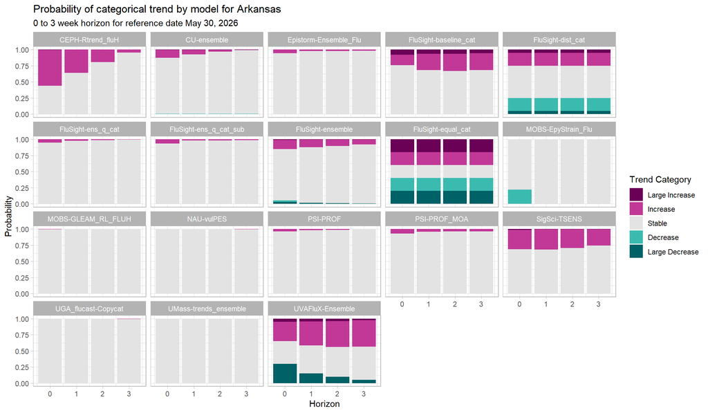

### California

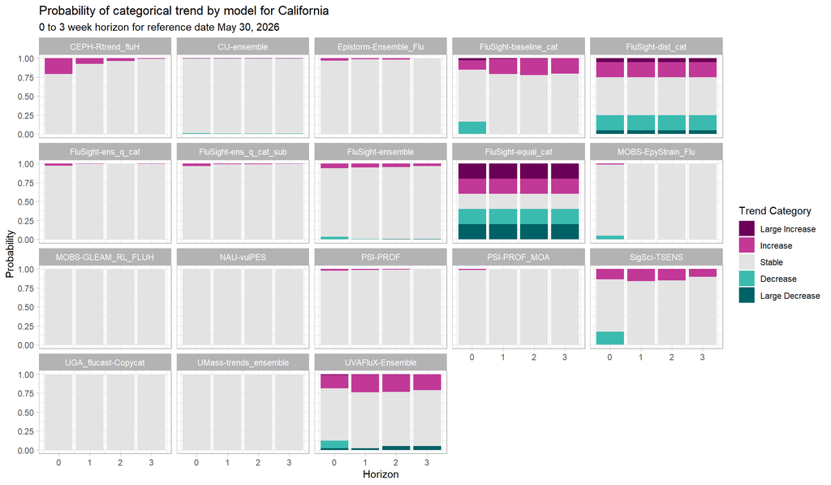

### Colorado

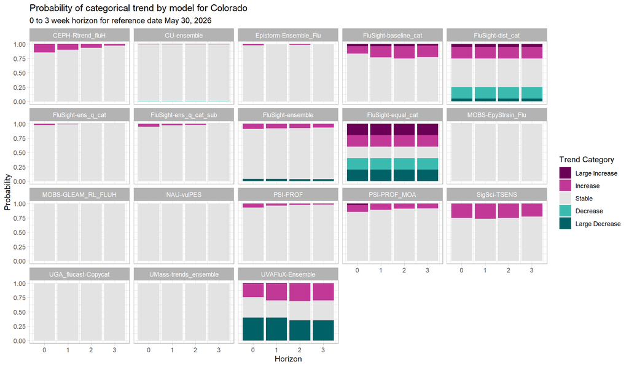

### Connecticut

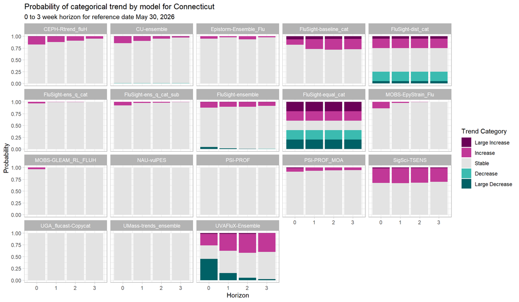

### Delaware

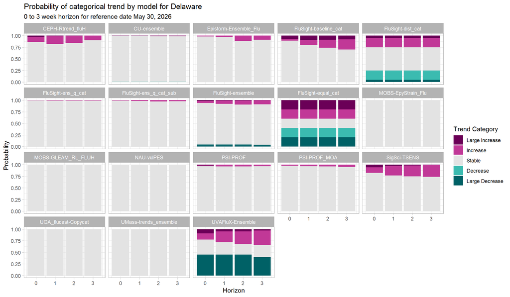

### District of Columbia

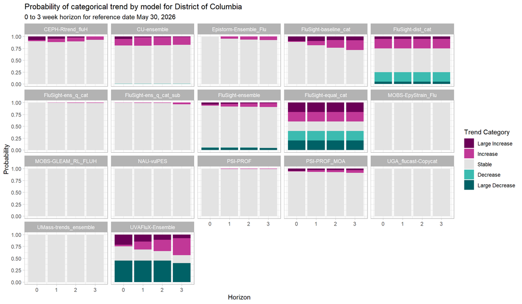

### Florida

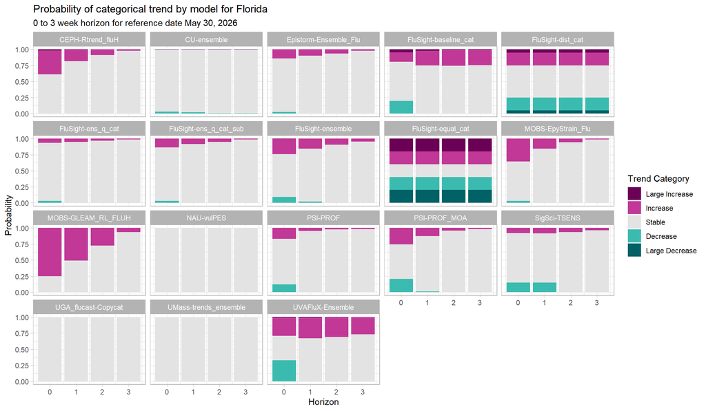

### Georgia

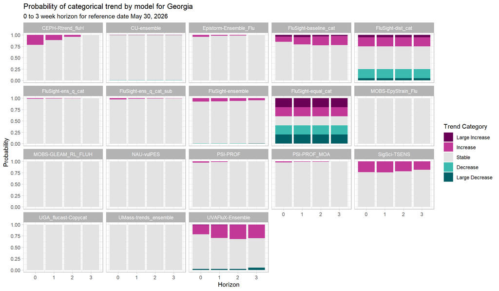

### Hawaii

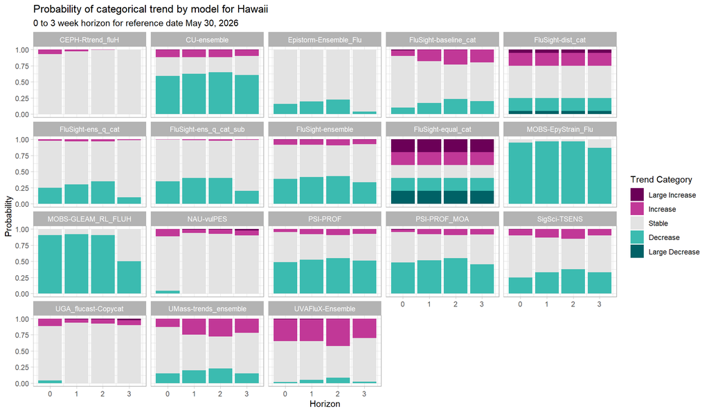

### Idaho

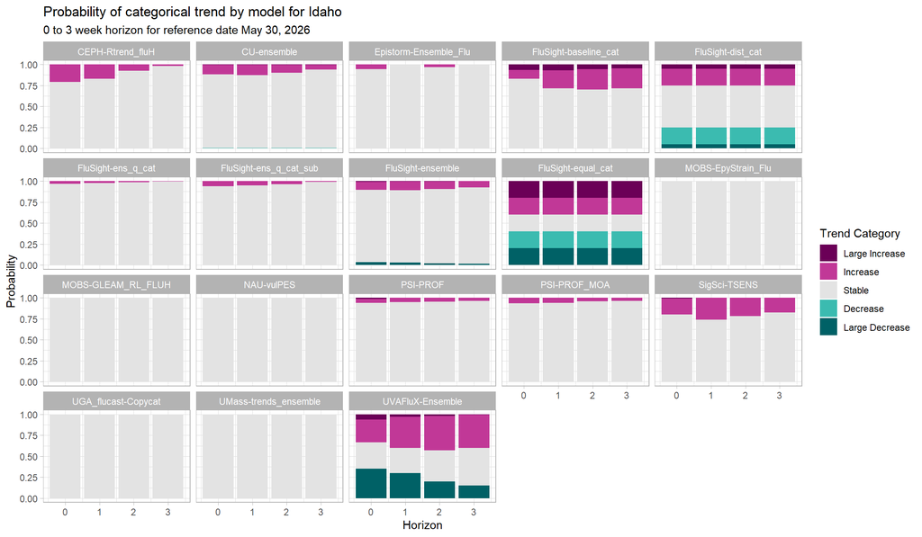

### Illinois

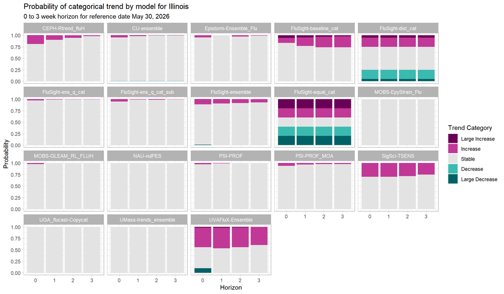

### Indiana

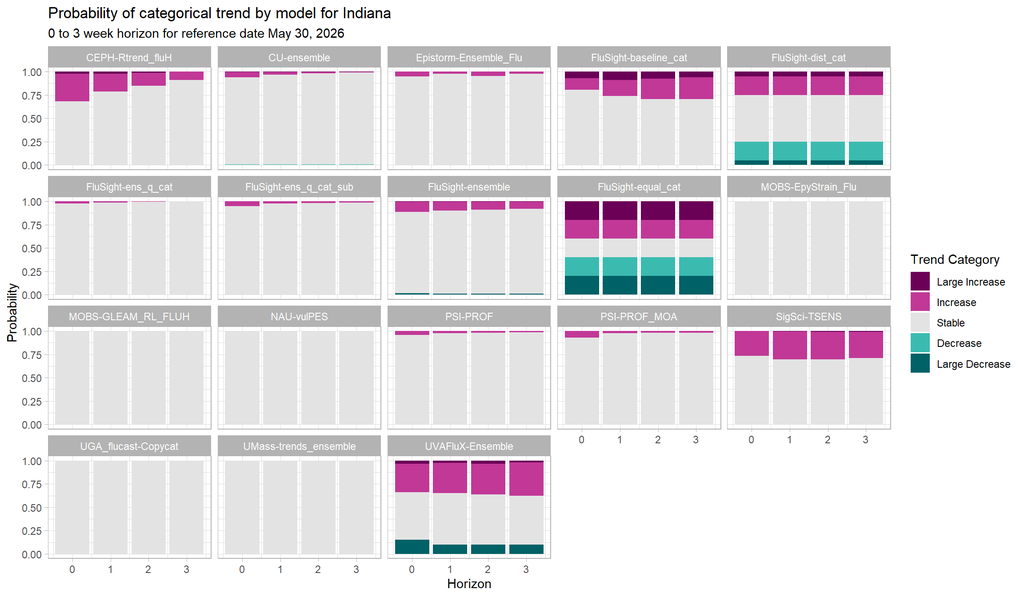

### Iowa

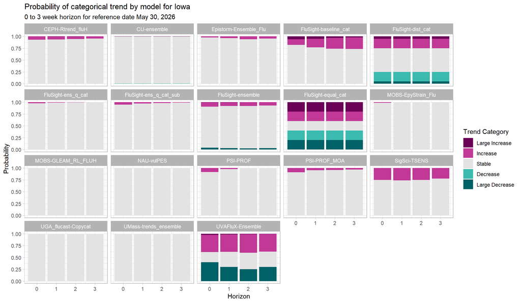

### Kansas

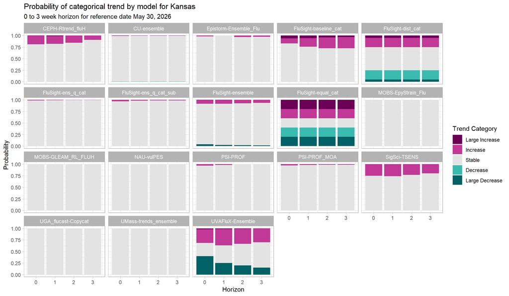

### Kentucky

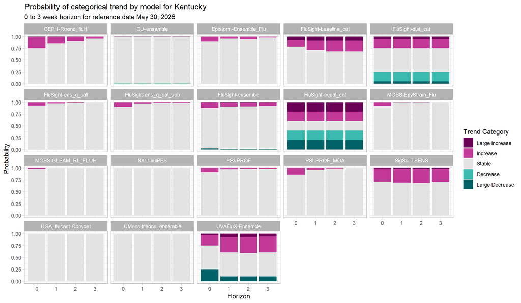

### Louisiana

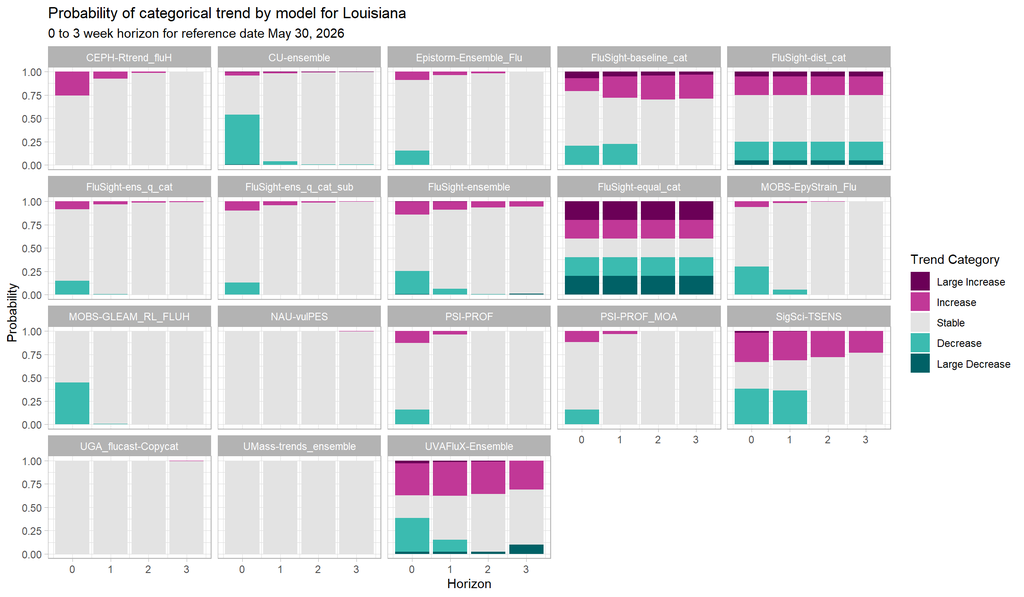

### Maine

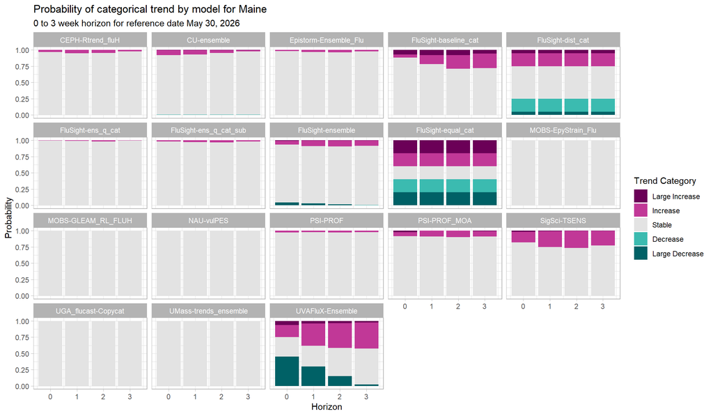

### Maryland

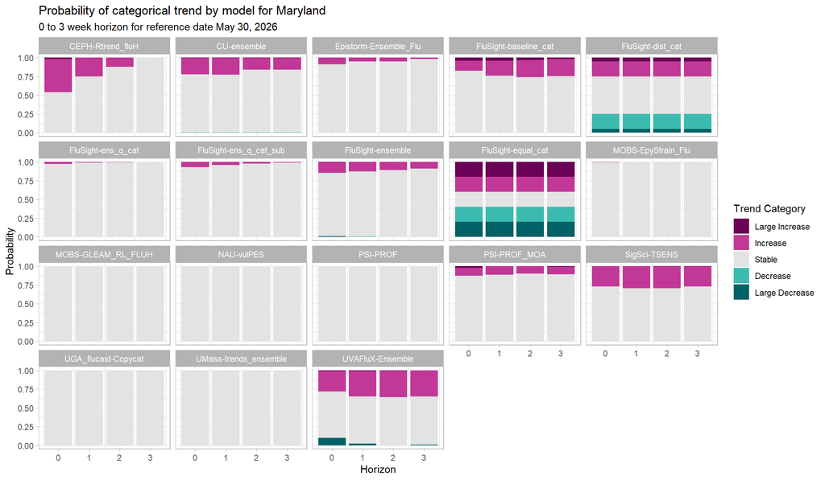

### Massachusetts

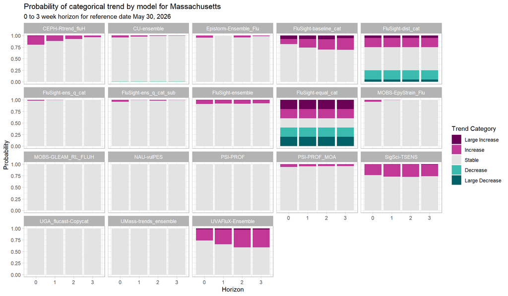

### Michigan

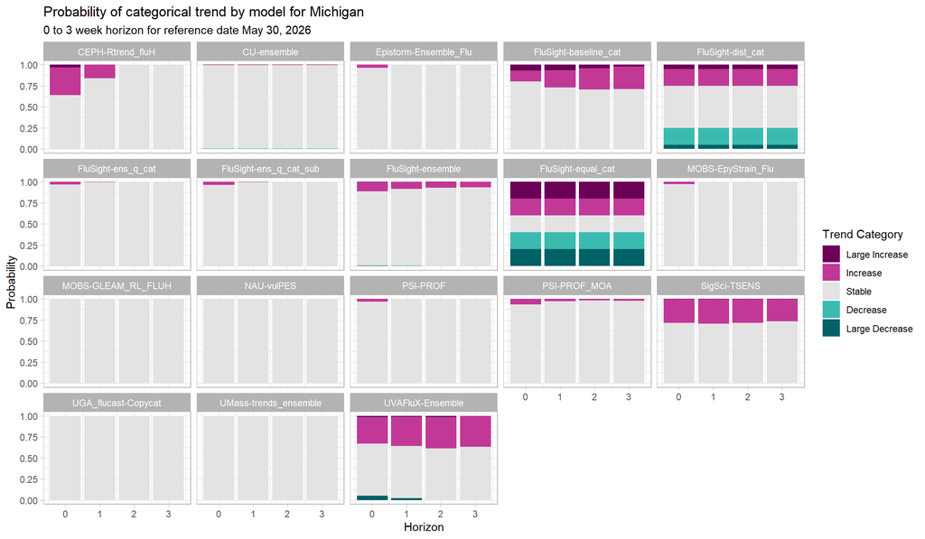

### Minnesota

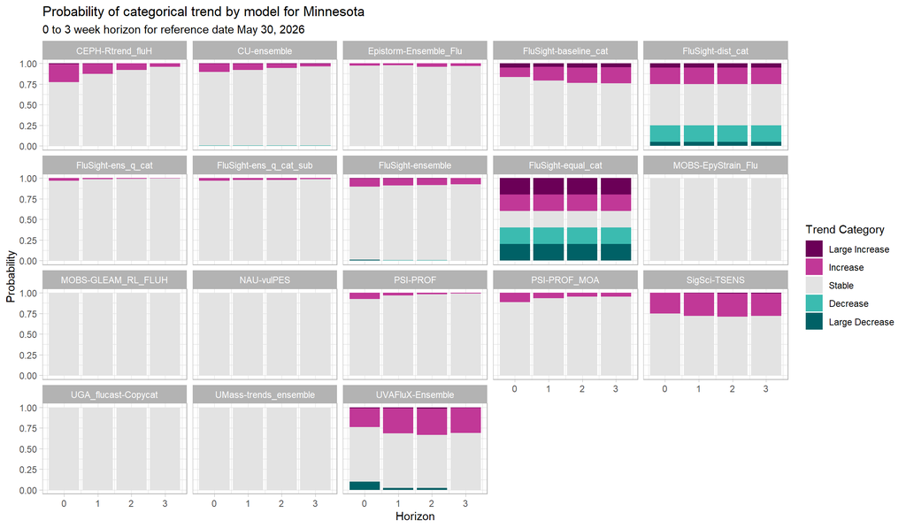

### Mississippi

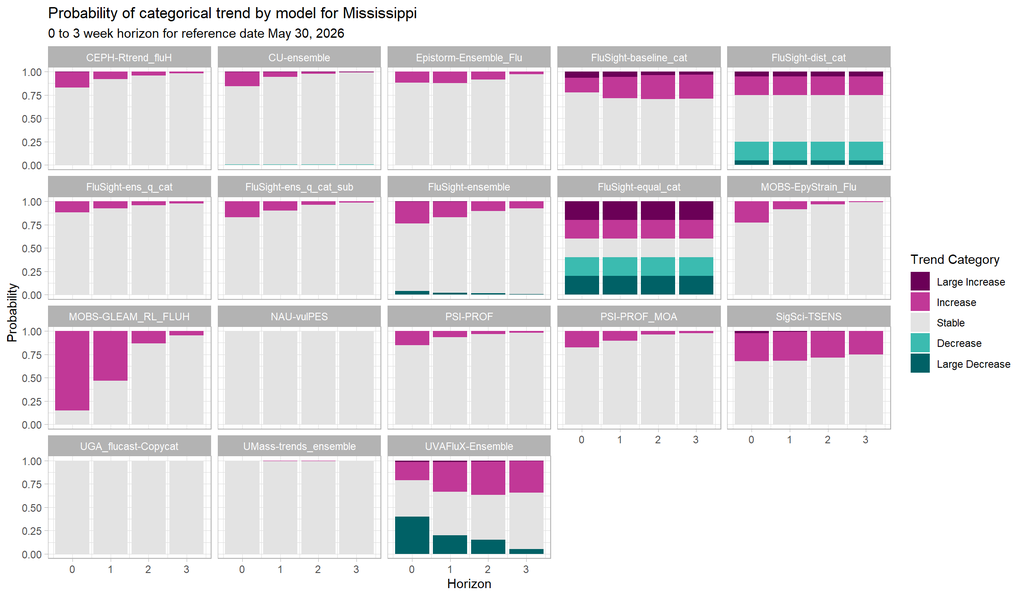

### Missouri

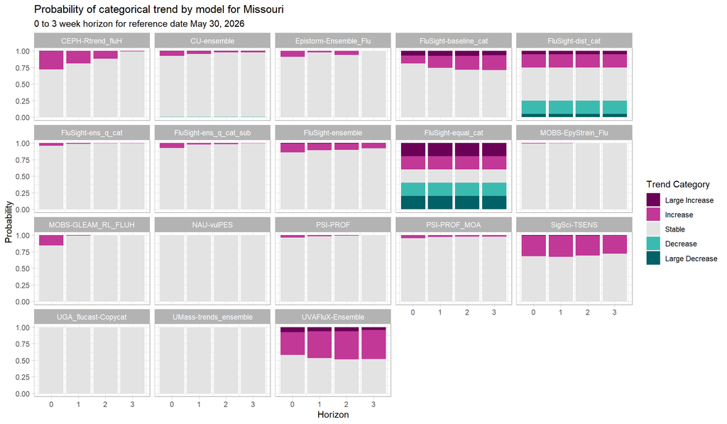

### Montana

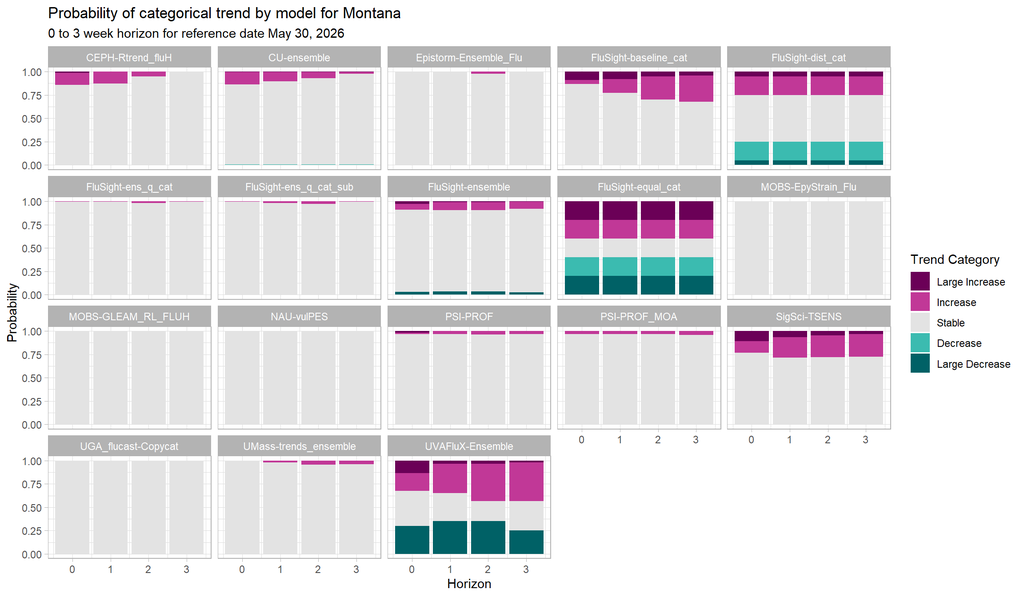

### Nebraska

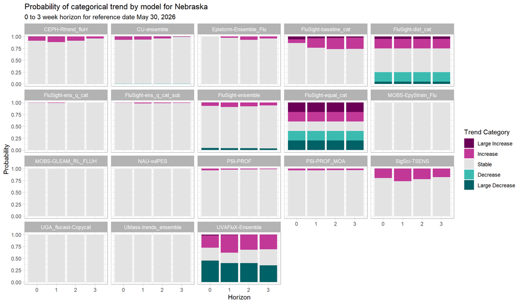

### Nevada

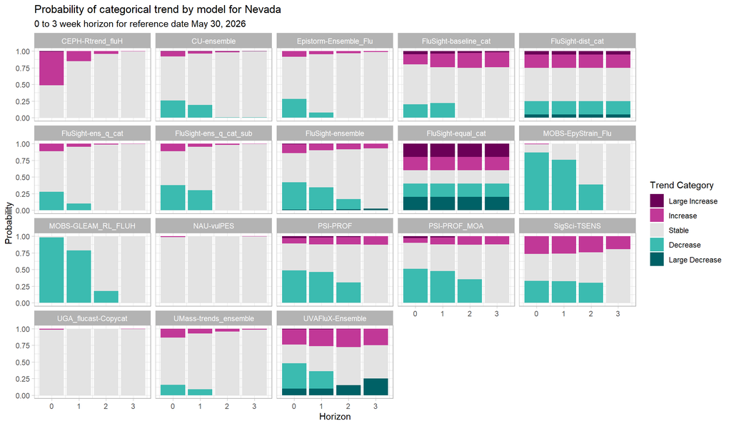

### New Hampshire

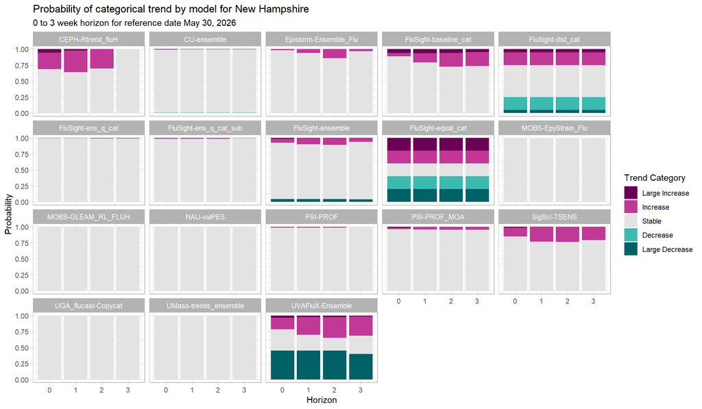

### New Jersey

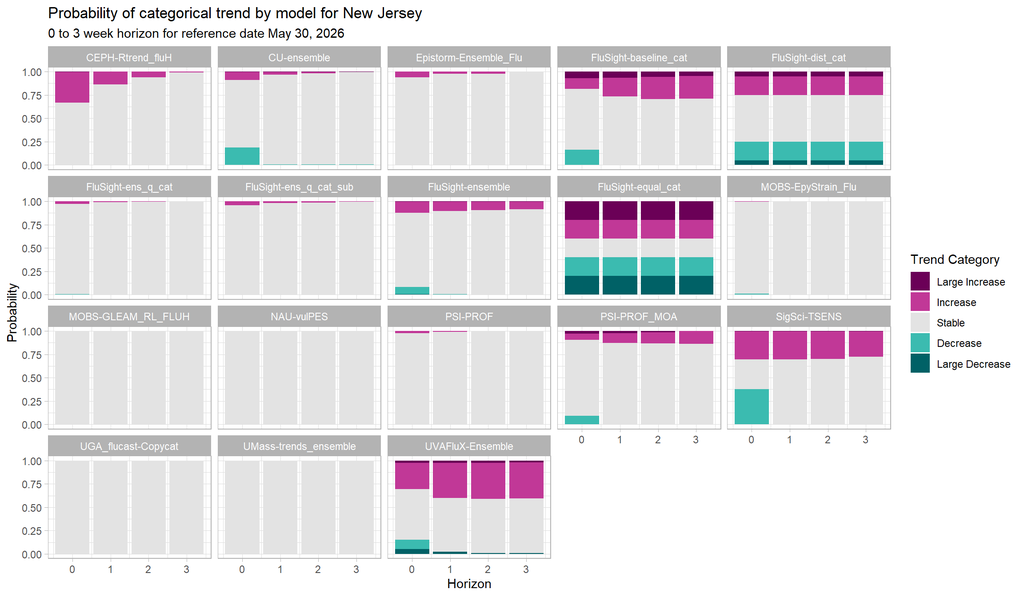

### New Mexico

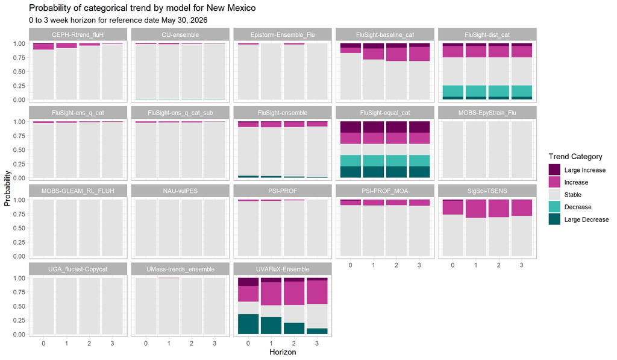

### New York

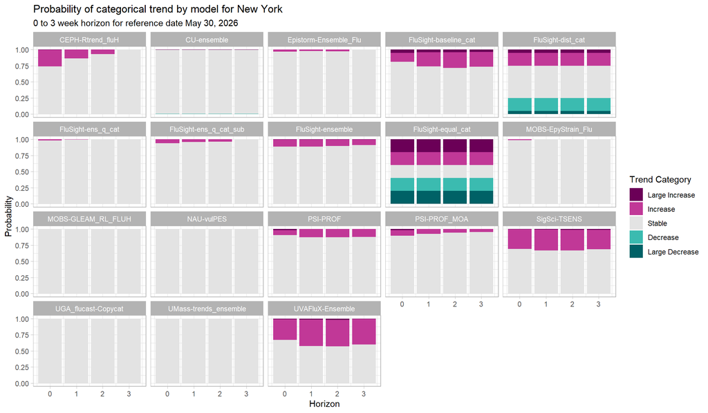

### North Carolina

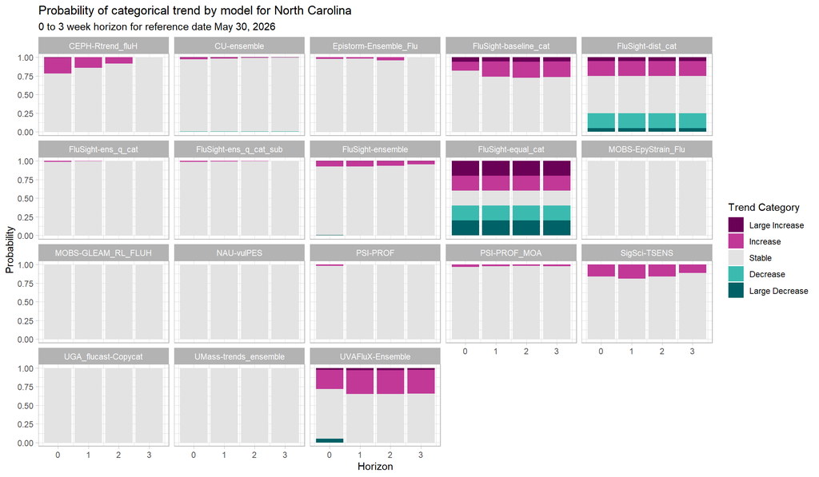

### North Dakota

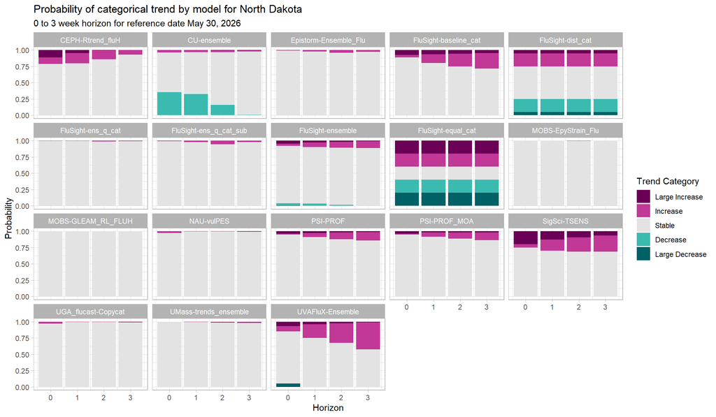

### Ohio

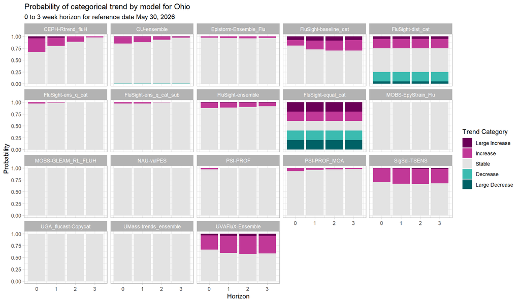

### Oklahoma

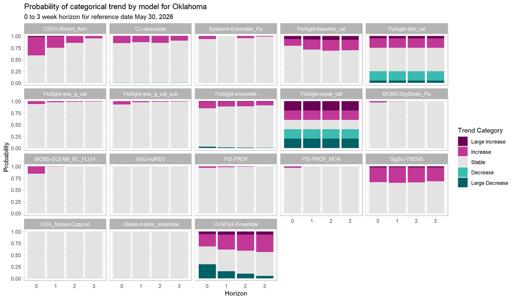

### Oregon

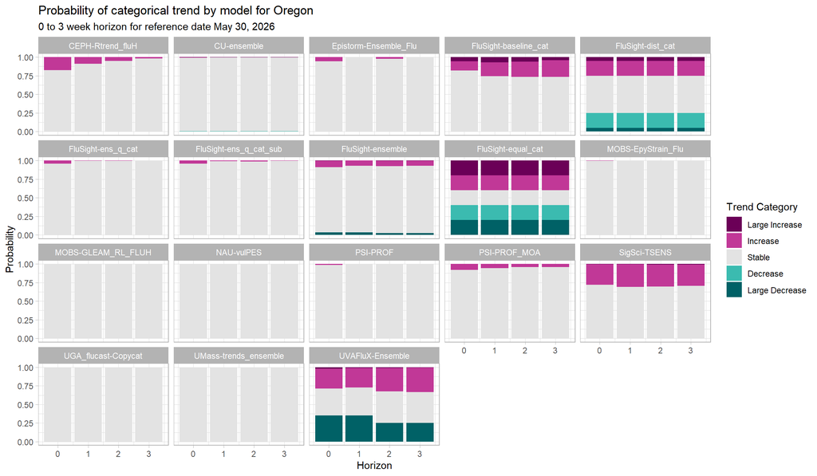

### Pennsylvania

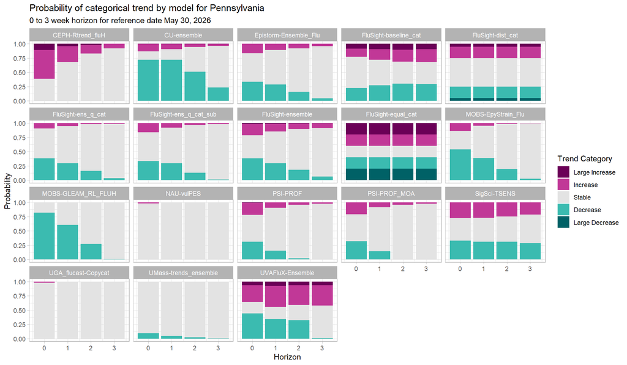

### Puerto Rico

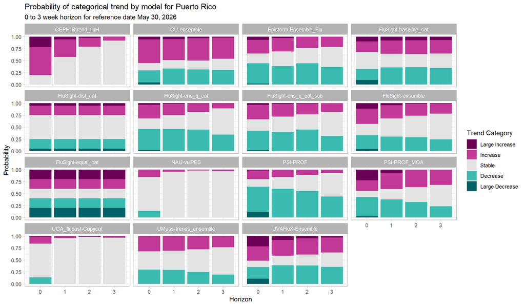

### Rhode Island

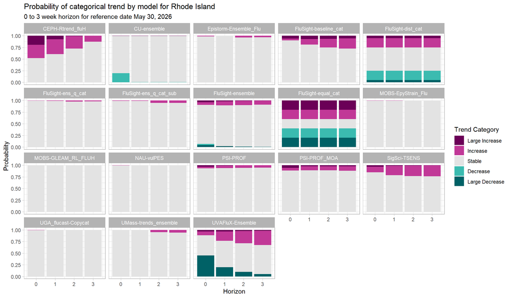

### South Carolina

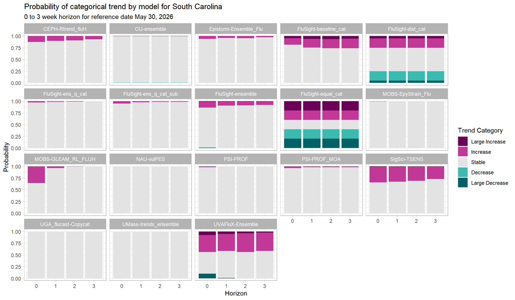

### South Dakota

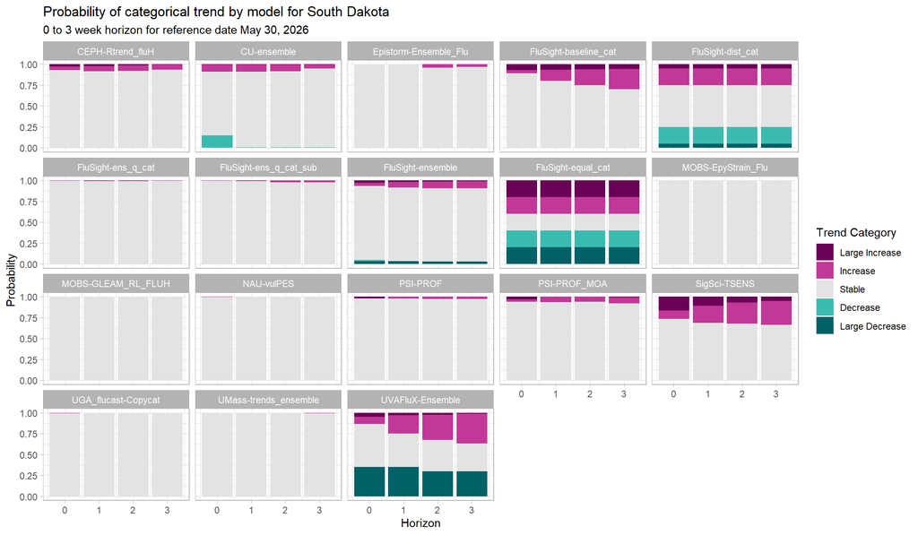

### Tennessee

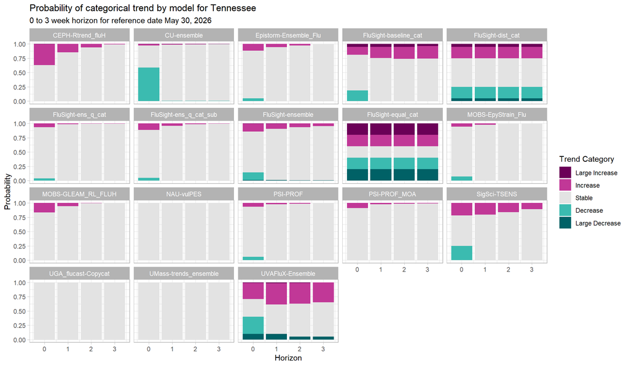